# Using devRate package on *T. solanivora* (Lepidoptera: Gelechiidae) in Ecuador

Francois Rebaudo, using data from Crespo-Perez et al. 2011

2017-10-17

This vignette exemplifies the use of the devRate package to fit a development rate model to an empirical dataset (laboratory experiments at air constant temperatures) and to build a simple phenological model.

The preliminary step is to perform an experiment where your arthropod study model is reared at different constant air temperatures, and to monitor the time at which your individuals change of life stage (e.g., eggs to larva). The monitoring of life stages is commonly expressed in development rate, corresponding to the inverse of the time to reach the next life stage. The time is often expressed in days. For example, if an individual takes 10 days from eggs to larva at 15 degrees Celsius, the development rate is 1/10 = 0.1. In this vignette we used a dataset from the literature.

The dataset for *T. solanivora* was retrieved from Crespo-Perez et al. 2011[^1], using Web Plot Digitizer[^2]. The dataset is also included in the package in the exTropicalMoth object. This object structure may seem complicated as it is composed of the laboratory data and the results of the modeling. It was designed to reduce the length of examples in the manual. In this vignette we present how to organize your own dataset from scratch.

## Organizing the dataset

In this example *T. solanivora* was reared at different temperatures with various repetitions for each temperature and different temperatures for the different life stages:

- the eggs were reared at 10, 13, 15, 15.5, 16, 17, 20, 25, 30, and 35 degrees
- the larva were reared at 10, 13, 15, 15.5, 17, 20, 25, 30, and 35 degrees
- the pupa were reared at 10, 13, 15, 15.5, 16, 17, 20, 25, 30, and 35 degrees.

The development rates were monitored at all these temperatures with various repetitions for each temperature.

The resulting dataset looks like the following table (for eggs development), where the first column corresponds to the temperature and the second column to the development rate.

| Temperature | Development Rate |
| --- | --- |
| 10.0 | 0.031 |
| 10.0 | 0.039 |
| 13.0 | 0.072 |
| … | … |

If the dataset is stored into a file, it can be read directly from that file (e.g., using *read.table()*). In this example, we copy-pasted the experimental results to create vectors and data frames.

```r
### Experimental temperatures and development rate for the eggs
expeTempEggs <- c(10.0, 10.0, 13.0, 15.0, 15.0, 15.5, 16.0, 16.0, 17.0, 20.0, 20.0,
              25.0, 25.0, 30.0, 30.0, 35.0)
expeDevEggs <- c(0.031, 0.039, 0.072, 0.047, 0.059, 0.066, 0.083, 0.1, 0.1, 0.1, 0.143,
             0.171, 0.2, 0.2, 0.18, 0.001)
dfDevEggs <- data.frame(expeTempEggs, expeDevEggs)

### Experimental temperatures and development rate for the larva
expeTempLarva <- c(10.0, 10.0, 10.0, 13.0, 15.0, 15.5, 15.5, 15.5, 17.0, 20.0, 25.0,
                   25.0, 30.0, 35.0)
expeDevLarva <- c(0.01, 0.014, 0.019, 0.034, 0.024, 0.029, 0.034, 0.039, 0.067, 0.05,
                  0.076, 0.056, 0.0003, 0.0002)
dfDevLarva <- data.frame(expeTempLarva, expeDevLarva)

### Experimental temperatures and development rate for the pupa
expeTempPupa <- c(10.0, 10.0, 10.0, 13.0, 15.0, 15.0, 15.5, 15.5, 16.0, 16.0, 17.0,
                  20.0, 20.0, 25.0, 25.0, 30.0, 35.0)
expeDevPupa <- c(0.001, 0.008, 0.012, 0.044, 0.017, 0.044, 0.039, 0.037, 0.034, 0.051, 0.051, 0.08, 0.092, 0.102, 0.073, 0.005, 0.0002)
dfDevPupa <- data.frame(expeTempPupa, expeDevPupa)

### Same dataset included in the package in the form of matrices
library("devRate")
data(exTropicalMoth)
str(exTropicalMoth[[1]])
```

```
## List of 3
##  $ eggs : num [1:16, 1:2] 10 10 13 15 15 15.5 16 16 17 20 ...
##  $ larva: num [1:14, 1:2] 10 10 10 13 15 15.5 15.5 15.5 17 20 ...
##  $ pupa : num [1:17, 1:2] 10 10 10 13 15 15 15.5 15.5 16 16 ...
```

## Finding models in the literature

Before attempting to fit any model to the empirical data, the devRate function “devRateFind” search the database for previous articles fitting models to the organism, either by Order, Family, or species. The most used models are presented at the top of the data.frame.

```r
devRateFind(orderSP = "Lepidoptera")
```

```
##              equation occu paramNumb
## 1         campbell_74  108         2
## 2          lactin2_95   32         4
## 3          briere1_99   23         3
## 4           taylor_81   22         3
## 5           logan6_76   19         4
## 6          briere2_99   18         4
## 7         davidson_44   15         3
## 8      harcourtYee_82   13         4
## 9          logan10_76   12         5
## 10    hilbertLogan_83   10         5
## 11            wang_82    9         6
## 12 sharpeDeMichele_77    8         6
## 13         lactin1_95    8         3
## 14        analytis_77    7         5
## 15              poly4    5         5
## 16         stinner_74    4         4
## 17              poly2    4         3
## 18            lamb_92    4         4
## 19      kontodimas_04    4         3
## 20           damos_08    4         3
## 21 schoolfieldHigh_81    3         4
## 22     schoolfield_81    1         6
## 23          rootsq_82    1         2
## 24       wangengel_98    1         3
## 25        regniere_12    1         6
```

Here we can see that at the time of this vignette, campbell_74 model was used 108 times to characterize the relationship between development rate and temperature for the Lepidoptera Order, and the taylor_81 model 22 times.

```r
devRateFind(familySP = "Gelechiidae")
```

```
##          equation occu paramNumb
## 1     campbell_74   12         2
## 2      lactin2_95    7         4
## 3       logan6_76    4         4
## 4      lactin1_95    4         3
## 5      briere1_99    4         3
## 6        damos_08    4         3
## 7     analytis_77    3         5
## 8       taylor_81    2         3
## 9      logan10_76    1         5
## 10 harcourtYee_82    1         4
## 11          poly4    1         5
## 12      rootsq_82    1         2
```

If we focus on the Family (Gelechiidae), campbell_74 has been used 12 times, lactin2_95 7 times, logan6_76 4 times, lactin1_95 4 times, briere1_99 4 times, damos_08 4 times, analytis_77 3 times, taylor_81 2 times, and so on (this may change as the database is growing).

```r
devRateFind(species = "Tecia solanivora")
```

```
## [1] equation occu
## <0 rows> (or 0-length row.names)
```

Unfortunately, the species *Tecia solanivora* is not in the package database at this time, so that we have to find a closely related species.

The “devRateInfo” function provides additional information on these models and on parameter estimations.

```r
devRateInfo(eq = taylor_81)
```

```
## ----------------------------------------
## Gauss
## ----------------------------------------
## Taylor, F. (1981) Ecology and evolution of physiological time in insects.
## American Naturalist, 1-23. \nLamb, RJ. (1992) Developmental rate of
## Acyrthosiphon pisum (Homoptera: Aphididae) at low temperatures: implications
## for estimating rate parameters for insects. Environmental Entomology 21(1):
## 10-19.
##
## rT ~ Rm * exp(-1/2 * ((T - Tm)/To)^2)
## <environment: namespace:devRate>
##
## Parameter estimates from the literature (eq$startVal):
##
##        ordersp      familysp        genussp         species
```

[output cut: 241 more lines]

```r
devRateInfo(eq = lactin1_95)
```

```
## ----------------------------------------
## Lactin-1
## ----------------------------------------
## Lactin, Derek J, NJ Holliday, DL Johnson, y R Craigen (1995) Improved rate
## model of temperature-dependent development by arthropods. Environmental
## Entomology 24(1): 68-75.
##
## rT ~ exp(aa * T) - exp(aa * Tmax - (Tmax - T)/deltaT)
## <environment: namespace:devRate>
##
## Parameter estimates from the literature (eq$startVal):
##
##        ordersp      familysp       genussp      species
## 1   Coleoptera Chrysomelidae  Leptinotarsa decemlineata
## 2   Coleoptera Chrysomelidae  Leptinotarsa decemlineata
```

[output cut: 66 more lines]

Here we can see for example that *Symmetrischema tangolias* study by Sporleder et al. 2016 has used the taylor_81 model, and that *Phthorimaea operculella* study by Golizadeh et al. 2012 has used the lactin1_95 model.

To return only the information on the closely related species, a specific query can be performed on the model.

```r
taylor_81$startVal[taylor_81$startVal["genSp"] == "Symmetrischema tangolias",]
```

```
##        ordersp    familysp        genussp   species
## 64 Lepidoptera Gelechiidae Symmetrischema tangolias
## 65 Lepidoptera Gelechiidae Symmetrischema tangolias
##                       genSp stage param.Rm param.Tm param.To
## 64 Symmetrischema tangolias larva   0.0476    28.58     10.5
## 65 Symmetrischema tangolias  pupa   0.0990    31.80     11.1
##                      ref
## 64 Sporleder et al. 2016
## 65 Sporleder et al. 2016
```

```r
lactin1_95$startVal[lactin1_95$startVal["genSp"] == "Phthorimaea operculella",]
```

```
##        ordersp    familysp     genussp     species                   genSp
## 12 Lepidoptera Gelechiidae Phthorimaea operculella Phthorimaea operculella
## 13 Lepidoptera Gelechiidae Phthorimaea operculella Phthorimaea operculella
## 14 Lepidoptera Gelechiidae Phthorimaea operculella Phthorimaea operculella
##    stage param.aa param.Tmax param.deltaT                   ref
## 12  eggs    0.177     36.586        5.631 Golizadeh et al. 2012
## 13 larva    0.169     37.914        5.912 Golizadeh et al. 2012
## 14  pupa    0.193     36.291        5.180 Golizadeh et al. 2012
```

Information from the database can be plotted using the “devRatePlotInfo” function if we want to have a first look on the taylor_81 or lactin1_95 models.

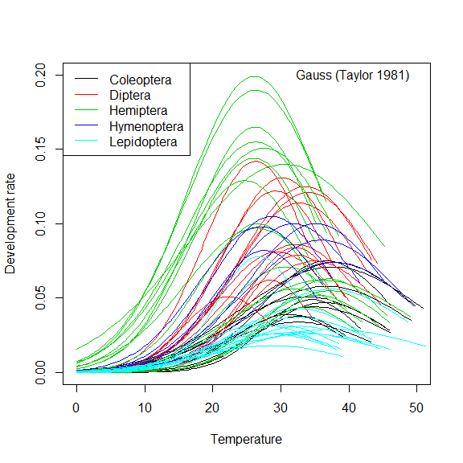

```r
devRatePlotInfo (eq = taylor_81, sortBy = "ordersp",
  ylim = c(0, 0.20), xlim = c(0, 50))
```

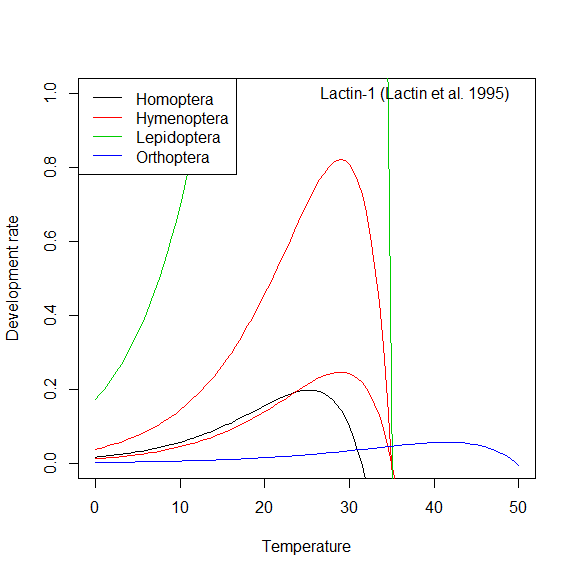

```r
devRatePlotInfo (eq = lactin1_95, sortBy = "ordersp",
  ylim = c(0, 1.00), xlim = c(0, 50))
```

In the case that no models were selected a priori because of the research goal (e.g., determination of a thermal metric), the taylor_81 or lactin1_95 models can be used as candidate models.

## Fitting models to empirical datasets

Now that we have model candidates and starting parameter estimates from closely related species, we can start the fitting process with our empirical data (NLS fit). The empirical data can be fitted to any model in the database with the “devRateModel” function, which returns an object of class “nls”.

```r
### using the vectors from section "Organizing the dataset"
############################################################

### for the taylor_81 model
mEggs01 <- devRateModel(eq = taylor_81,
  temp = expeTempEggs,
  devRate = expeDevEggs,
  startValues = list(Rm = 0.05, Tm = 30, To = 5))

mLarva01 <- devRateModel(eq = taylor_81,
  temp = expeTempLarva,
  devRate = expeDevLarva,
  startValues = list(Rm = 0.05, Tm = 25, To = 10))

mPupa01 <- devRateModel(eq = taylor_81,
  temp = expeTempPupa,
  devRate = expeDevPupa,
  startValues = list(Rm = 0.1, Tm = 30, To = 10))

### for the lactin1_95 model
mEggs01b <- devRateModel(eq = lactin1_95,
  temp = expeTempEggs,
  devRate = expeDevEggs,
  startValues = list(aa = 0.177, Tmax = 36.586, deltaT = 5.631))

# mLarva01b <- devRateModel(eq = lactin1_95,
#   temp = expeTempLarva,
#   devRate = expeDevLarva,
#   startValues = list(aa = 0.169, Tmax = 37.914, deltaT = 5.912))
### The algorithm has not found a solution after 50 iterations
### One possibility is to increase the maximum number of iterations
### using the "control" argument (see ?nls() for more details).

mLarva01b <- devRateModel(eq = lactin1_95,
  temp = expeTempLarva,
  devRate = expeDevLarva,
  startValues = list(aa = 0.169, Tmax = 37.914, deltaT = 5.912),
  control = list(maxiter = 500))

mPupa01b <- devRateModel(eq = lactin1_95,
  temp = expeTempPupa,
  devRate = expeDevPupa,
  startValues = list(aa = 0.193, Tmax = 36.291, deltaT = 5.18),
  control = list(maxiter = 500))

### using the data frames from section "Organizing the dataset"
############################################################

mEggs02 <- devRateModel(eq = taylor_81,
  df = dfDevEggs,
  startValues = list(Rm = 0.05, Tm = 30, To = 5))

mLarva02 <- devRateModel(eq = taylor_81,
  df = dfDevLarva,
  startValues = list(Rm = 0.05, Tm = 25, To = 10))

mPupa02 <- devRateModel(eq = taylor_81,
  df = dfDevPupa,
  startValues = list(Rm = 0.1, Tm = 30, To = 10))

### using the dataset included in the package (only for taylor_81 model)
############################################################

mEggs <- devRateModel(eq = taylor_81,
  temp = exTropicalMoth$raw$eggs[,1],
  devRate = exTropicalMoth$raw$eggs[,2],
  startValues = list(Rm = 0.05, Tm = 30, To = 5))

mLarva <- devRateModel(eq = taylor_81,
  temp = exTropicalMoth$raw$larva[,1],
  devRate = exTropicalMoth$raw$larva[,2],
  startValues = list(Rm = 0.05, Tm = 25, To = 10))

mPupa <- devRateModel(eq = taylor_81,
  temp = exTropicalMoth$raw$pupa[,1],
  devRate = exTropicalMoth$raw$pupa[,2],
  startValues = list(Rm = 0.1, Tm = 30, To = 10))
```

The summary of the “devRateModel” can be obtained with the “devRatePrint” function.

```r
resultNLS <- devRatePrint(myNLS = mLarva,
  temp = exTropicalMoth$raw$larva[,1],
  devRate = exTropicalMoth$raw$larva[,2])
```

```
## ##################################################
## ### Parameter estimates and overall model fit
## ##################################################
##
## Formula: rT ~ Rm * exp(-1/2 * ((T - Tm)/To)^2)
##
## Parameters:
##     Estimate Std. Error t value Pr(>|t|)
## Rm  0.068383   0.009473   7.219 1.71e-05 ***
## Tm 21.408732   0.729062  29.365 8.41e-12 ***
## To  5.544986   0.865264   6.408 5.02e-05 ***
## ---
## Signif. codes:  0 '***' 0.001 '**' 0.01 '*' 0.05 '.' 0.1 ' ' 1
##
## Residual standard error: 0.0133 on 11 degrees of freedom
##
## Number of iterations to convergence: 13
## Achieved convergence tolerance: 6.653e-06
##
## ##################################################
## ### Confidence intervals for parameters
## ##################################################
##          2.5 %      97.5 %
## Rm  0.04981547  0.08694955
## Tm 19.97979621 22.83766817
## To  3.84909961  7.24087239
##
## ##################################################
## ### Residuals distribution and independence
## ##################################################
## ### Normality of the residual distribution
##
##  Shapiro-Wilk normality test
##
## data:  stats::residuals(myNLS)
## W = 0.97915, p-value = 0.9696
##
## ### Regression of the residuals against a lagged version of themselves
## ### and testing if the slope of the resulting relationship is significantly
## ### different from 0:
```

[output cut: 8 more lines]

```
## Coefficients:
##                               Estimate Std. Error t value Pr(>|t|)
## (Intercept)                  0.0005691  0.0036255   0.157    0.878
## stats::residuals(myNLS)[-1] -0.1654787  0.2965227  -0.558    0.588
##
## Residual standard error: 0.01307 on 11 degrees of freedom
## Multiple R-squared:  0.02753,    Adjusted R-squared:  -0.06087
## F-statistic: 0.3114 on 1 and 11 DF,  p-value: 0.588
##
## ##################################################
## ### Comparing models
## ##################################################
## ### Using AIC and BIC
## Akaike Information Criterion (AIC): -76.6001352945075
## Bayesian Information Criterion (BIC): -74.0439059760465
```

```r
resultNLSb <- devRatePrint(myNLS = mLarva01b,
  temp = exTropicalMoth$raw$larva[,1],
  devRate = exTropicalMoth$raw$larva[,2])
```

```
## ##################################################
## ### Parameter estimates and overall model fit
## ##################################################
##
## Formula: rT ~ exp(aa * T) - exp(aa * Tmax - (Tmax - T)/deltaT)
##
## Parameters:
##        Estimate Std. Error t value Pr(>|t|)
## aa      0.10600    0.02346   4.519 0.000874 ***
## Tmax   34.36276    1.09320  31.433 4.01e-12 ***
## deltaT  9.40117    2.05898   4.566 0.000809 ***
## ---
## Signif. codes:  0 '***' 0.001 '**' 0.01 '*' 0.05 '.' 0.1 ' ' 1
##
## Residual standard error: 0.01864 on 11 degrees of freedom
##
## Number of iterations to convergence: 103
## Achieved convergence tolerance: 8.166e-06
##
## ##################################################
## ### Confidence intervals for parameters
## ##################################################
##             2.5 %     97.5 %
## aa      0.0600211  0.1519774
## Tmax   32.2201227 36.5053899
## deltaT  5.3656469 13.4366907
##
## ##################################################
## ### Residuals distribution and independence
## ##################################################
## ### Normality of the residual distribution
##
##  Shapiro-Wilk normality test
##
## data:  stats::residuals(myNLS)
## W = 0.95297, p-value = 0.6077
##
## ### Regression of the residuals against a lagged version of themselves
## ### and testing if the slope of the resulting relationship is significantly
## ### different from 0:
```

[output cut: 8 more lines]

```
## Coefficients:
##                              Estimate Std. Error t value Pr(>|t|)
## (Intercept)                 -0.001559   0.005071  -0.307    0.764
## stats::residuals(myNLS)[-1]  0.073340   0.306144   0.240    0.815
##
## Residual standard error: 0.01828 on 11 degrees of freedom
## Multiple R-squared:  0.00519,    Adjusted R-squared:  -0.08525
## F-statistic: 0.05739 on 1 and 11 DF,  p-value: 0.8151
##
## ##################################################
## ### Comparing models
## ##################################################
## ### Using AIC and BIC
## Akaike Information Criterion (AIC): -67.1607406799357
## Bayesian Information Criterion (BIC): -64.6045113614747
```

Empirical data can be plotted against the model using the “devRatePlot” function.

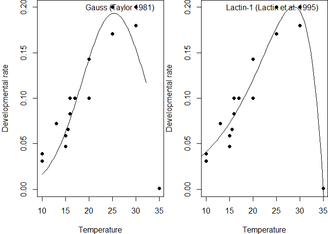

```r
par(mfrow = c(1, 2), mar = c(4, 4, 0, 0))
devRatePlot(eq = taylor_81,
  nlsDR = mEggs,
  temp = exTropicalMoth$raw$eggs[,1],
  devRate = exTropicalMoth$raw$eggs[,2],
  pch = 16, ylim = c(0, 0.2))

devRatePlot(eq = lactin1_95,
  nlsDR = mEggs01b,
  temp = exTropicalMoth$raw$eggs[,1],
  devRate = exTropicalMoth$raw$eggs[,2],
  pch = 16, ylim = c(0, 0.2))
```

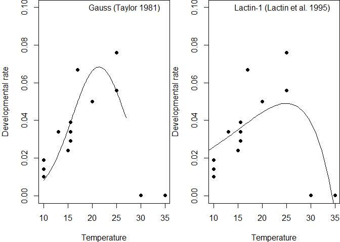

```r
devRatePlot(eq = taylor_81,
  nlsDR = mLarva,
  temp = exTropicalMoth$raw$larva[,1],
  devRate = exTropicalMoth$raw$larva[,2],
  pch = 16, ylim = c(0, 0.1))

devRatePlot(eq = lactin1_95,
  nlsDR = mLarva01b,
  temp = exTropicalMoth$raw$larva[,1],
  devRate = exTropicalMoth$raw$larva[,2],
  pch = 16, ylim = c(0, 0.1))
```

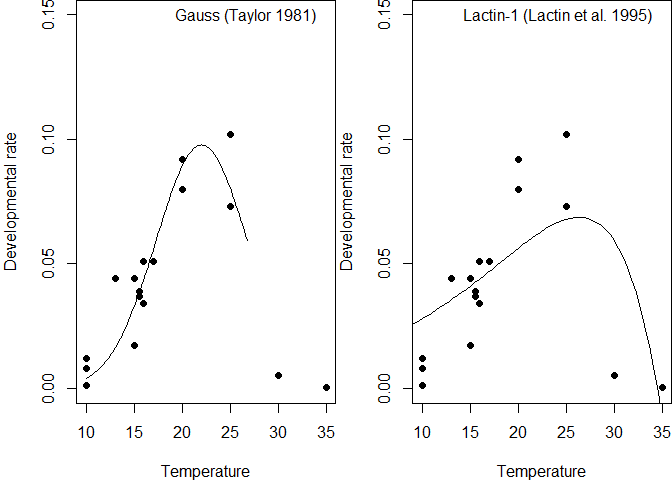

```r
devRatePlot(eq = taylor_81,
  nlsDR = mPupa,
  temp = exTropicalMoth$raw$pupa[,1],
  devRate = exTropicalMoth$raw$pupa[,2],
  pch = 16, ylim = c(0, 0.15))

devRatePlot(eq = lactin1_95,
  nlsDR = mPupa01b,
  temp = exTropicalMoth$raw$pupa[,1],
  devRate = exTropicalMoth$raw$pupa[,2],
  pch = 16, ylim = c(0, 0.15))
```

## Models comparison

Models can be compared using the AIC or any function compatible with an “nls” object, such as BIC or logLik (see the R manual for the use and interpretation of these functions, outside of the scope of this vignette).

```r
### Models for the larva life stage
c(AIC(mLarva), AIC(mLarva01b))
```

```
## [1] -76.60014 -67.16074
```

```r
c(BIC(mLarva), BIC(mLarva01b))
```

```
## [1] -74.04391 -64.60451
```

```r
c(logLik(mLarva), logLik(mLarva01b))
```

```
## [1] 42.30007 37.58037
```

## Forecasting phenologies from empirical temperature

From the “nls” object obtained above, we can build a simple phenology model using temperature time series (e.g., to forecast the organism outbreaks). In this example the temperature dataset is built from a Normal distribution of mean 15 and a standard deviation of 1, with a time step of one day. The development models used are those previously fitted with the Taylor model for the three stages. We assumed that the average time for female adults to lay eggs was of 1 day. We simulated 50 individuals, with a stochasticity in development rate centered on the development rate, with a standard deviation of 0.015 (Normal distribution).

```r
forecastTsolanivora <- devRateIBM(
  tempTS = rnorm(n = 100, mean = 15, sd = 1),
  timeStepTS = 1,
  models = list(mEggs, mLarva, mPupa),
  numInd = 50,
  stocha = 0.015,
  timeLayEggs = 1)
print(forecastTsolanivora)
```

```
## [[1]]
##       g1s1 g1s2 g1s3 g2s1
##  [1,]   16   48   76   91
##  [2,]   17   46   71   88
##  [3,]   17   44   73   89
##  [4,]   19   50   81   98
##  [5,]   20   50   79   95
##  [6,]   16   43   73   87
##  [7,]   17   48   80   95
##  [8,]   17   44   78   93
##  [9,]   17   45   79   98
## [10,]   18   47   80   97
## [11,]   19   49   78   98
## [12,]   17   49   80   97
## [13,]   17   46   77   93
## [14,]   18   48   81   98
## [15,]   19   50   80   96
## [16,]   16   46   79   96
## [17,]   18   47   80   98
## [18,]   18   46   81   99
## [19,]   19   54   85   NA
## [20,]   18   49   77   92
## [21,]   17   45   73   92
## [22,]   16   46   72   88
## [23,]   19   49   79   94
## [24,]   18   45   78   93
## [25,]   16   47   80   97
## [26,]   16   48   81   98
## [27,]   17   44   74   90
## [28,]   17   47   81   98
## [29,]   18   44   74   90
## [30,]   17   45   78   93
## [31,]   20   46   77   92
## [32,]   15   45   77   94
## [33,]   16   45   80   95
## [34,]   17   46   77   93
## [35,]   18   46   77   91
## [36,]   17   48   80   97
## [37,]   16   48   83   NA
## [38,]   18   46   80   96
```

[output cut: 49 more lines]

```
##   [1] 15.08717 14.13917 14.69259 13.89968 14.51723 14.56265 14.46420
##   [8] 14.30875 13.07095 15.51554 14.77187 14.76677 13.76546 14.42929
##  [15] 16.23992 17.39729 15.19926 14.05261 14.79270 15.88017 15.14433
##  [22] 14.51188 16.00228 16.00136 15.66029 15.25931 16.37277 15.47359
##  [29] 14.80287 13.42780 13.51618 14.72929 14.67732 14.77652 13.74241
##  [36] 14.91819 16.29803 14.08647 14.77589 14.97184 15.85502 14.70589
##  [43] 13.43626 15.78591 13.34995 16.19943 12.91605 15.95971 13.72409
##  [50] 16.39064 14.01880 15.00564 13.96519 15.36538 15.97482 15.33349
##  [57] 15.41414 14.88086 14.99089 13.99743 17.11897 15.41349 15.03996
##  [64] 14.12918 15.79352 13.97583 13.37527 12.34994 14.45555 13.80742
##  [71] 16.61982 14.96486 14.97945 14.20383 13.34039 12.33877 15.44264
##  [78] 14.83817 14.88384 15.77332 15.78708 15.24639 15.50869 16.51268
##  [85] 14.82239 15.41804 14.66941 14.57900 18.34496 14.92180 14.83583
##  [92] 13.27677 14.63561 12.62634 14.61841 13.50935 14.75389 15.79490
##  [99] 15.76641 15.13374
```

Results can be plotted using the “devRateIBMPlot” function. From this simple model we can observe that if eggs of the first generation are laid at time t = 0, adults should be seen at t = [65:85], if the temperature time series correspond to the temperatures experienced by the organism and in the absence of other limiting factors.

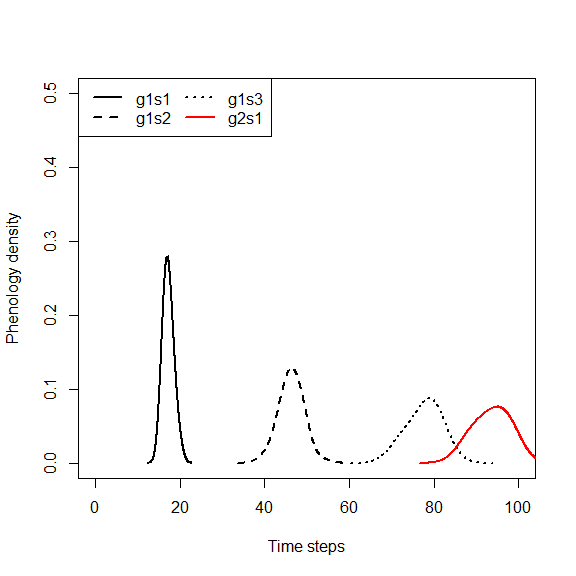

```
## Threshold for visualization = 10% of individuals
```

```r
devRateIBMPlot(ibm = forecastTsolanivora, typeG = "density")
```

[^1]: Crespo-Pérez, V., Rebaudo, F., Silvain, J.-F. and Dangles, O. (2011) Modeling invasive species spread in complex landscapes: the case of potato moth in Ecuador. Landscape Ecology, 26, 1447–1461.
[^2]: Rohatgi, A. (2015) WebPlotDigitalizer: HTML5 Based Online Tool to Extract Numerical Data from Plot Images.